# glinski_metabolites

# tested hypotheses

- observed vivo versus in vitro degradation rates are the same, or observed vivo rates are lower than in vitro rates (due to other degradation processes, uptake kinetics?)
- first order kinetics are michaelis-menton, second order
- are in vitro indicative of in vivo

# things to do

- michaelis menton first order comparison for both experiments
- non-linear goodness of fit

# install and load supporting libraries

```
##          nodename
## "DZ2626UTPURUCKE"
```

```
## [1] "R version 3.4.3 (2017-11-30)"
```

```
##
## 'drc' has been loaded.
```

```
## for references type 'citation()' and 'citation('drc')'.
```

```
## [1] "list of loaded packages: "
##  [1] "pbkrtest"      "lme4"          "Matrix"        "scatterplot3d"
##  [5] "ggplot2"       "drc"           "MASS"          "xtable"
##  [9] "zoo"           "knitr"         "dplyr"         "rmarkdown"
## [13] "stats"         "graphics"      "grDevices"     "utils"
## [17] "datasets"      "methods"       "base"
```

# import experimental exposure and microsomal data

Load csv files with experimental data and microsome data sets. The beolw may return false but still be OK if rstudio does not have privileges to data directory (e.g., attached drive).

```
## [1] "Root directory location: d:/git/glinski_metabolites/"
```

```
## [1] "check to see if R can access files OK: FALSE"
```

```
##      time      parent     analyte     matrix        conc replicate
## 4      15    atrazine    atrazine microsomes   0.5514354         1
## 47      0    atrazine    atrazine microsomes          NA         1
## 61     90    atrazine    atrazine microsomes          NA         3
## 92      0    atrazine    atrazine microsomes 697.4815010         1
## 95     15    atrazine    atrazine microsomes 161.9606512         1
## 98     30    atrazine    atrazine microsomes 237.9761898         1
## 101    60    atrazine    atrazine microsomes 255.9782700         1
## 104    90    atrazine    atrazine microsomes 121.3271776         1
## 127     0    atrazine    atrazine microsomes          NA         1
## 134    31    atrazine    atrazine microsomes          NA         2
## 169    60    atrazine         dea microsomes   0.3080022         4
## 206    15    atrazine         dea microsomes          NA         1
## 209    30    atrazine         dea microsomes          NA         1
## 212    60    atrazine         dea microsomes          NA         1
```

[output cut: 73 more lines]

# experimental exposure data structure

Check out structure of imported data sets.

```
## 'data.frame':    352 obs. of  6 variables:
##  $ time     : int  2 2 2 2 4 4 4 4 12 12 ...
##  $ parent   : Factor w/ 3 levels "atrazine","fipronil",..: 1 1 1 1 1 1 1 1 1 1 ...
##  $ analyte  : Factor w/ 8 levels "ATZ","DEA","DIA",..: 1 1 1 1 1 1 1 1 1 1 ...
##  $ matrix   : Factor w/ 2 levels "amphib","soil": 1 1 1 1 1 1 1 1 1 1 ...
##  $ conc     : num  3.07 3.69 4.7 1.89 7.62 ...
##  $ replicate: int  1 2 3 4 1 2 3 4 1 2 ...
```

Set time and replicate fields as factors for later statistical inference.

# microsome experiment data structure

Check out structure of imported data set for the microsome analysis.

```
## 'data.frame':    994 obs. of  8 variables:
##  $ time     : int  0 0 0 15 15 30 30 30 60 60 ...
##  $ parent   : Factor w/ 3 levels "atrazine","fipronil",..: 1 1 1 1 1 1 1 1 1 1 ...
##  $ analyte  : Factor w/ 8 levels "atrazine","dea",..: 1 1 1 1 1 1 1 1 1 1 ...
##  $ matrix   : Factor w/ 1 level "microsomes": 1 1 1 1 1 1 1 1 1 1 ...
##  $ conc     : num  1.21 1.6 1.36 1.35 1.21 ...
##  $ replicate: int  1 2 3 2 3 1 2 3 1 2 ...
##  $ microMexp: num  0.712 0.712 0.712 0.712 0.712 0.712 0.712 0.712 0.712 0.712 ...
##  $ X        : logi  NA NA NA NA NA NA ...
```

Set time and replicate fields as factors for later statistical inference.

```
## 'data.frame':    994 obs. of  8 variables:
##  $ time     : int  0 0 0 15 15 30 30 30 60 60 ...
##  $ parent   : Factor w/ 3 levels "atrazine","fipronil",..: 1 1 1 1 1 1 1 1 1 1 ...
##  $ analyte  : Factor w/ 8 levels "atrazine","dea",..: 1 1 1 1 1 1 1 1 1 1 ...
##  $ matrix   : Factor w/ 1 level "microsomes": 1 1 1 1 1 1 1 1 1 1 ...
##  $ conc     : num  1.21 1.6 1.36 1.35 1.21 ...
##  $ replicate: Factor w/ 4 levels "1","2","3","4": 1 2 3 2 3 1 2 3 1 2 ...
##  $ microMexp: num  0.712 0.712 0.712 0.712 0.712 0.712 0.712 0.712 0.712 0.712 ...
##  $ X        : logi  NA NA NA NA NA NA ...
```

# analyze microsomal data

The microsomal experiment has 3-4 replicates for each pesticide. The experiment progressively increases the concentration of the substrate (microMexp) and measures the enzyme velocity. At each substrate concentration the reaction is quenched after a specific period of time (0, 15, 30, 60, 90 mins). This time series data is used to estimate a slope associated with each substrate concentration. Substrate concentration and linear velocity slopes are then fit using Michaelis-Menten kinetics to estimate reaction rates for each pesticide.

# non-linear fitting

We use the dose-response model (drm) package from R for the fitting of the rate constant. We provide it the 2-parameter Michaelis-Menton function (mm2) as an argument. It uses the MM.2 function that is in the drc package and therefore is a drc object that contains a list of class drcMean, containing the mean function, the self starter function, the parameter names and other components such as derivatives and a function for calculating ED values. It is not shifted (??) so uses the fit f(x,(c,d,e)) = c + (d-c)/(1+e/x). Where x is the dose, it is a strictly increasing function so we reverse the sign of the slopes for the parents. e is the dose halfway between c and d, for the 2-parameter model c = 0.

```
## Michaelis-Menten
## (2 parameters)
## In 'drc':  MM.2
```

# atrazine

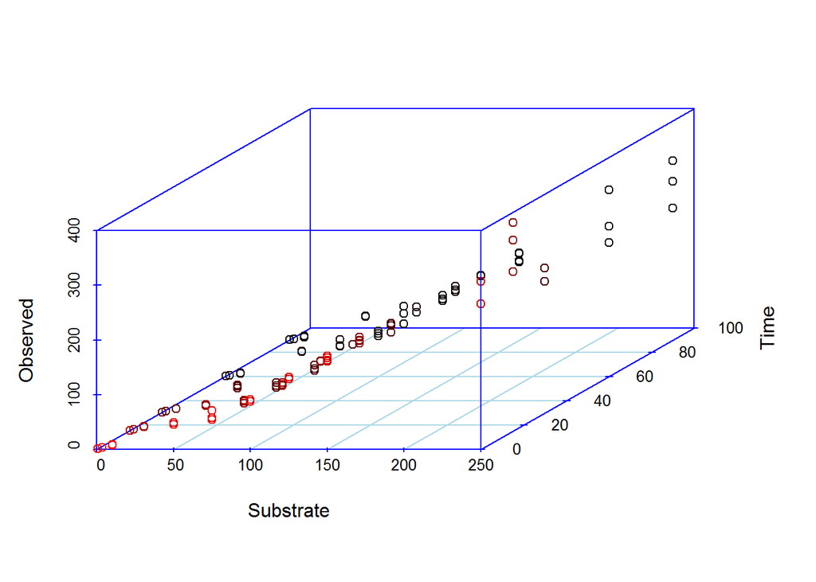

The above figure shows a three-dimensional plot of pesticide substrate concentration, observed concentration and experiment time. We need to condition the pesticide data on the substrate concentrations used in the experiment and regress the observed concentrations over the 90 min period in order to estimate the linear slopes for the Michaelis-Menten kinetic rate constants.

```
## [1] "Substrates:"
```

```
## [1] "##################################################"
## [1] "Substrate =  0.712"
##       ind
##  [1,]   1  0 1.2080499
##  [2,]   2  0 1.5958074
##  [3,]   3  0 1.3622627
##  [4,]   4 15 1.3469113
##  [5,]   5 15 1.2124448
##  [6,]   6 30 1.1349183
##  [7,]   7 30 1.0824669
##  [8,]   8 30 1.1138895
##  [9,]   9 60 0.9180152
## [10,]  10 60 0.8199161
## [11,]  11 60 0.8304017
## [12,]  12 90 0.6019329
## [13,]  13 90 0.5146155
## [14,]  14 90 0.5430465
## [1] "least squares linear regression for substrate = 0.712"
##
## Call:
## lm(formula = Observed[ind] ~ Time[ind])
##
## Coefficients:
## (Intercept)    Time[ind]
##    1.398706    -0.009293
##
##
## Call:
## lm(formula = Observed[ind] ~ Time[ind])
##
## Residuals:
##      Min       1Q   Median       3Q      Max
## -0.19066 -0.03719 -0.01498  0.03347  0.19710
##
## Coefficients:
##               Estimate Std. Error t value Pr(>|t|)
## (Intercept)  1.3987059  0.0386612   36.18 1.27e-13 ***
## Time[ind]   -0.0092933  0.0007396  -12.56 2.89e-08 ***
## ---
## Signif. codes:  0 '***' 0.001 '**' 0.01 '*' 0.05 '.' 0.1 ' ' 1
##
## Residual standard error: 0.09072 on 12 degrees of freedom
## Multiple R-squared:  0.9294, Adjusted R-squared:  0.9235
## F-statistic: 157.9 on 1 and 12 DF,  p-value: 2.893e-08
##
## (Intercept)   Time[ind]
##  1.39870589 -0.00929334
##                   2.5 %       97.5 %
## (Intercept)  1.31447036  1.482941425
## Time[ind]   -0.01090489 -0.007681791
```

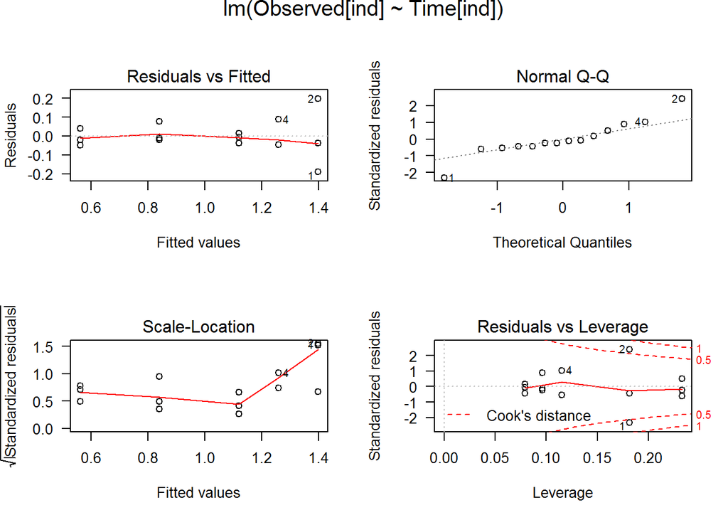

```
## [1] "weighted linear regression for substrate = 0.712"
## Call:
## rlm(formula = Observed[ind] ~ Time[ind])
## Converged in 9 iterations
##
## Coefficients:
##  (Intercept)    Time[ind]
##  1.391987016 -0.009212117
##
## Degrees of freedom: 14 total; 12 residual
## Scale estimate: 0.0535
##
## Call: rlm(formula = Observed[ind] ~ Time[ind])
## Residuals:
##     Min      1Q  Median      3Q     Max
## -0.1839 -0.0323 -0.0141  0.0341  0.2038
##
## Coefficients:
##             Value    Std. Error t value
## (Intercept)   1.3920   0.0314    44.3291
## Time[ind]    -0.0092   0.0006   -15.3343
##
## Residual standard error: 0.05352 on 12 degrees of freedom
```

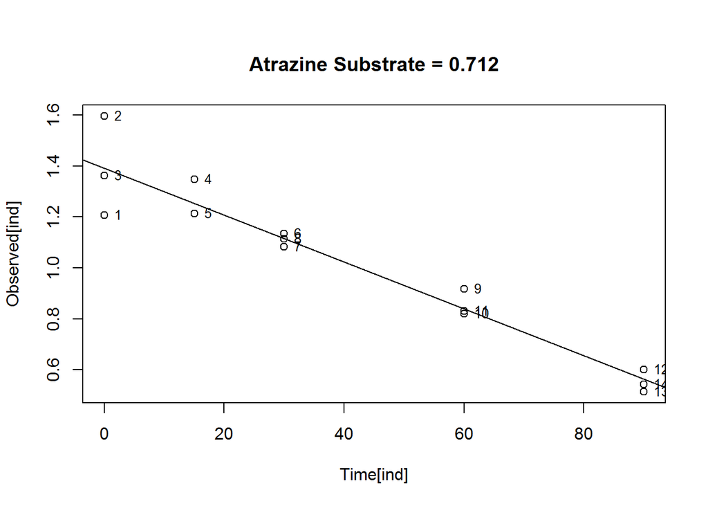

```
##  (Intercept)    Time[ind]
##  1.391987016 -0.009212117
##             2.5 % 97.5 %
## (Intercept)    NA     NA
## Time[ind]      NA     NA
## [1] "##################################################"
## [1] "##################################################"
## [1] "Substrate =  10"
##       ind
##  [1,]  15  0 7.925056
##  [2,]  16  0 8.535005
##  [3,]  17  0 7.899000
##  [4,]  18 15 8.712917
##  [5,]  19 15 8.046755
##  [6,]  20 15 8.073616
##  [7,]  21 30 7.256438
##  [8,]  22 30 7.355159
##  [9,]  23 30 7.326464
## [10,]  24 60 5.106467
## [11,]  25 60 6.116857
## [12,]  26 60 6.612799
## [13,]  27 60 6.416351
## [14,]  28 90 7.579707
## [15,]  29 90 5.426896
## [16,]  30 90 5.468859
## [1] "least squares linear regression for substrate = 10"
##
## Call:
## lm(formula = Observed[ind] ~ Time[ind])
##
## Coefficients:
## (Intercept)    Time[ind]
##     8.22302     -0.02746
##
##
## Call:
## lm(formula = Observed[ind] ~ Time[ind])
##
## Residuals:
##     Min      1Q  Median      3Q     Max
## -1.4691 -0.3045 -0.1079  0.2423  1.8278
##
## Coefficients:
##              Estimate Std. Error t value Pr(>|t|)
## (Intercept)  8.223019   0.289635  28.391 8.92e-14 ***
## Time[ind]   -0.027457   0.005648  -4.861 0.000252 ***
## ---
## Signif. codes:  0 '***' 0.001 '**' 0.01 '*' 0.05 '.' 0.1 ' ' 1
##
## Residual standard error: 0.7161 on 14 degrees of freedom
## Multiple R-squared:  0.628,  Adjusted R-squared:  0.6014
## F-statistic: 23.63 on 1 and 14 DF,  p-value: 0.0002518
##
## (Intercept)   Time[ind]
##  8.22301942 -0.02745731
##                   2.5 %      97.5 %
## (Intercept)  7.60181496  8.84422388
## Time[ind]   -0.03957117 -0.01534345
```

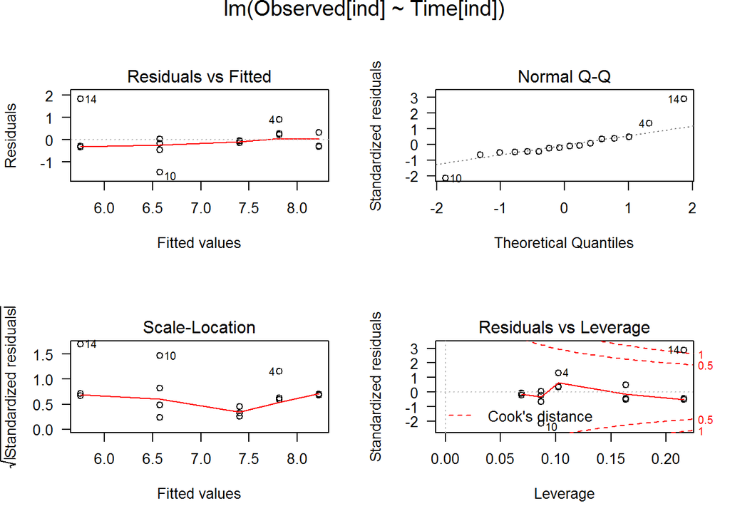

```
## [1] "weighted linear regression for substrate = 10"
## Call:
## rlm(formula = Observed[ind] ~ Time[ind])
## Converged in 5 iterations
##
## Coefficients:
## (Intercept)   Time[ind]
##  8.28012829 -0.03063472
##
## Degrees of freedom: 16 total; 14 residual
## Scale estimate: 0.355
##
## Call: rlm(formula = Observed[ind] ~ Time[ind])
## Residuals:
##      Min       1Q   Median       3Q      Max
## -1.33558 -0.15978 -0.03016  0.23286  2.05670
##
## Coefficients:
##             Value    Std. Error t value
## (Intercept)   8.2801   0.1561    53.0337
## Time[ind]    -0.0306   0.0030   -10.0619
##
## Residual standard error: 0.3552 on 14 degrees of freedom
```

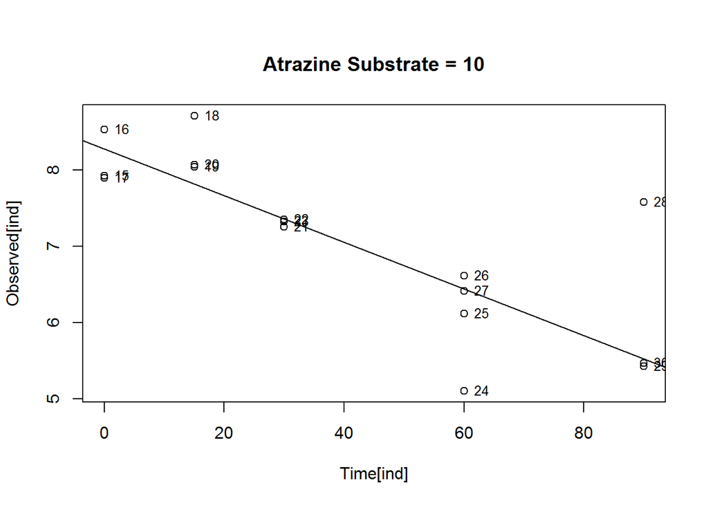

```
## (Intercept)   Time[ind]
##  8.28012829 -0.03063472
##             2.5 % 97.5 %
## (Intercept)    NA     NA
## Time[ind]      NA     NA
## [1] "##################################################"
## [1] "##################################################"
## [1] "Substrate =  3.1684"
##       ind
##  [1,]  31  0 3.856505
##  [2,]  32  0 3.856469
##  [3,]  33  0 4.000676
##  [4,]  34 15 3.592665
##  [5,]  35 15 3.566235
##  [6,]  36 15 3.407026
##  [7,]  37 30 3.230388
##  [8,]  38 30 3.182488
##  [9,]  39 30 3.039758
## [10,]  40 60 2.523246
## [11,]  41 60 2.351721
## [12,]  42 60 2.405224
## [13,]  43 90 1.868645
## [14,]  44 90 2.090715
## [15,]  45 90 1.793542
## [1] "least squares linear regression for substrate = 3.1684"
##
## Call:
## lm(formula = Observed[ind] ~ Time[ind])
##
## Coefficients:
## (Intercept)    Time[ind]
##      3.8540      -0.0223
##
##
## Call:
## lm(formula = Observed[ind] ~ Time[ind])
##
## Residuals:
##      Min       1Q   Median       3Q      Max
## -0.16435 -0.08220  0.00248  0.04602  0.24362
##
## Coefficients:
##               Estimate Std. Error t value Pr(>|t|)
## (Intercept)  3.8540242  0.0458583   84.04  < 2e-16 ***
## Time[ind]   -0.0222992  0.0009055  -24.63 2.71e-12 ***
## ---
## Signif. codes:  0 '***' 0.001 '**' 0.01 '*' 0.05 '.' 0.1 ' ' 1
##
## Residual standard error: 0.1133 on 13 degrees of freedom
## Multiple R-squared:  0.979,  Adjusted R-squared:  0.9774
## F-statistic: 606.5 on 1 and 13 DF,  p-value: 2.71e-12
##
## (Intercept)   Time[ind]
##  3.85402419 -0.02229925
##                  2.5 %     97.5 %
## (Intercept)  3.7549534  3.9530949
## Time[ind]   -0.0242554 -0.0203431
```

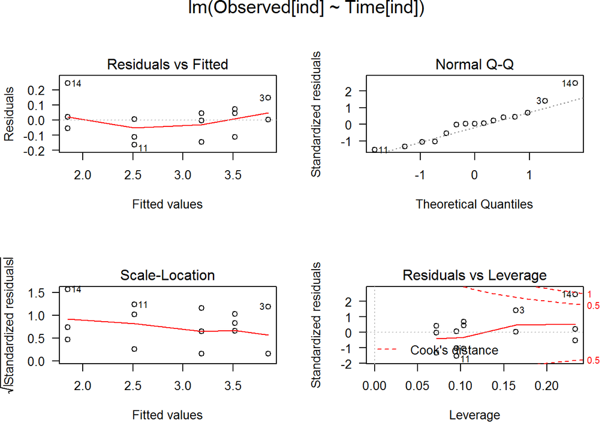

```
## [1] "weighted linear regression for substrate = 3.1684"
## Call:
## rlm(formula = Observed[ind] ~ Time[ind])
## Converged in 8 iterations
##
## Coefficients:
## (Intercept)   Time[ind]
##  3.86465594 -0.02275624
##
## Degrees of freedom: 15 total; 13 residual
## Scale estimate: 0.0772
##
## Call: rlm(formula = Observed[ind] ~ Time[ind])
## Residuals:
##        Min         1Q     Median         3Q        Max
## -0.1475603 -0.0585546  0.0005195  0.0502352  0.2741208
##
## Coefficients:
##             Value    Std. Error t value
## (Intercept)   3.8647   0.0496    77.8848
## Time[ind]    -0.0228   0.0010   -23.2266
##
## Residual standard error: 0.07717 on 13 degrees of freedom
```

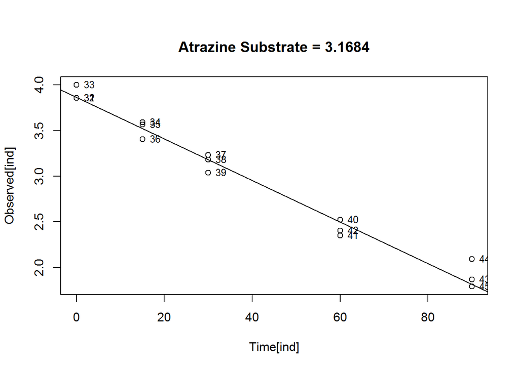

```
## (Intercept)   Time[ind]
##  3.86465594 -0.02275624
##             2.5 % 97.5 %
## (Intercept)    NA     NA
## Time[ind]      NA     NA
## [1] "##################################################"
## [1] "##################################################"
## [1] "Substrate =  50"
##       ind
##  [1,]  46  0 49.36255
##  [2,]  47  0 45.63559
##  [3,]  48 15 47.33018
##  [4,]  49 15 49.35531
##  [5,]  50 15 47.17151
##  [6,]  51 30 50.59649
##  [7,]  52 30 48.66029
##  [8,]  53 30 45.11503
##  [9,]  54 60 46.32181
## [10,]  55 60 45.69771
## [11,]  56 60 46.83574
## [12,]  57 90 44.33320
## [13,]  58 90 43.14627
## [1] "least squares linear regression for substrate = 50"
##
## Call:
## lm(formula = Observed[ind] ~ Time[ind])
##
## Coefficients:
## (Intercept)    Time[ind]
##    48.59636     -0.04483
##
##
## Call:
## lm(formula = Observed[ind] ~ Time[ind])
##
## Residuals:
##     Min      1Q  Median      3Q     Max
## -2.9608 -0.7524 -0.2088  0.9292  3.3450
##
## Coefficients:
##             Estimate Std. Error t value Pr(>|t|)
## (Intercept) 48.59636    0.78210  62.136 2.32e-15 ***
## Time[ind]   -0.04483    0.01618  -2.771   0.0182 *
## ---
## Signif. codes:  0 '***' 0.001 '**' 0.01 '*' 0.05 '.' 0.1 ' ' 1
##
## Residual standard error: 1.737 on 11 degrees of freedom
## Multiple R-squared:  0.411,  Adjusted R-squared:  0.3575
## F-statistic: 7.677 on 1 and 11 DF,  p-value: 0.0182
##
## (Intercept)   Time[ind]
## 48.59636117 -0.04483029
##                   2.5 %       97.5 %
## (Intercept) 46.87496515 50.317757197
## Time[ind]   -0.08044212 -0.009218455
```

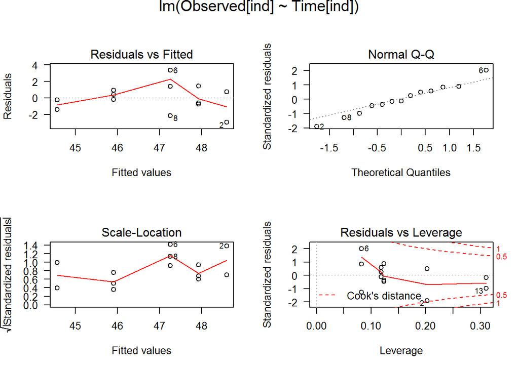

```
## [1] "weighted linear regression for substrate = 50"
## Call:
## rlm(formula = Observed[ind] ~ Time[ind])
## Converged in 6 iterations
##
## Coefficients:
## (Intercept)   Time[ind]
## 48.68982363 -0.04752188
##
## Degrees of freedom: 13 total; 11 residual
## Scale estimate: 1.48
##
## Call: rlm(formula = Observed[ind] ~ Time[ind])
## Residuals:
##      Min       1Q   Median       3Q      Max
## -3.05424 -0.80549 -0.07965  0.99723  3.33233
##
## Coefficients:
##             Value   Std. Error t value
## (Intercept) 48.6898  0.8305    58.6254
## Time[ind]   -0.0475  0.0172    -2.7658
##
## Residual standard error: 1.478 on 11 degrees of freedom
```

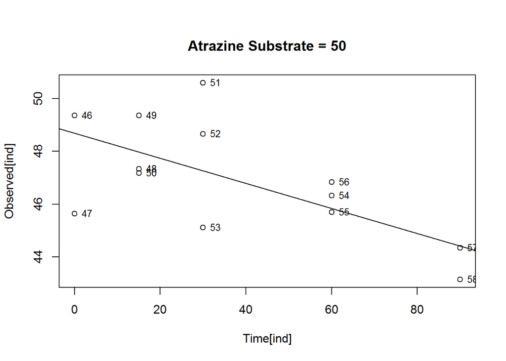

```
## (Intercept)   Time[ind]
## 48.68982363 -0.04752188
##             2.5 % 97.5 %
## (Intercept)    NA     NA
## Time[ind]      NA     NA
## [1] "##################################################"
## [1] "##################################################"
## [1] "Substrate =  75"
##       ind
##  [1,]  59  0 57.52955
##  [2,]  60  0 54.79227
##  [3,]  61  0 71.19048
##  [4,]  62 15 54.59374
##  [5,]  63 15 51.29412
##  [6,]  64 15 56.87161
##  [7,]  65 30 50.13677
##  [8,]  66 30 46.09059
##  [9,]  67 30 54.93692
## [10,]  68 60 55.87491
## [11,]  69 60 67.85864
## [12,]  70 60 55.49677
## [13,]  71 90 48.47103
## [14,]  72 90 61.24224
## [15,]  73 90 28.95872
## [1] "least squares linear regression for substrate = 75"
##
## Call:
## lm(formula = Observed[ind] ~ Time[ind])
##
## Coefficients:
## (Intercept)    Time[ind]
##     58.3096      -0.1014
##
##
## Call:
## lm(formula = Observed[ind] ~ Time[ind])
##
## Residuals:
##      Min       1Q   Median       3Q      Max
## -20.2269  -4.3244  -0.7146   3.4589  15.6317
##
## Coefficients:
##             Estimate Std. Error t value Pr(>|t|)
## (Intercept) 58.30963    3.80308   15.33 1.05e-09 ***
## Time[ind]   -0.10138    0.07509   -1.35      0.2
## ---
## Signif. codes:  0 '***' 0.001 '**' 0.01 '*' 0.05 '.' 0.1 ' ' 1
##
## Residual standard error: 9.397 on 13 degrees of freedom
## Multiple R-squared:  0.123,  Adjusted R-squared:  0.0555
## F-statistic: 1.823 on 1 and 13 DF,  p-value: 0.2
##
## (Intercept)   Time[ind]
##  58.3096265  -0.1013778
##                  2.5 %      97.5 %
## (Intercept) 50.0935756 66.52567748
## Time[ind]   -0.2636035  0.06084778
```

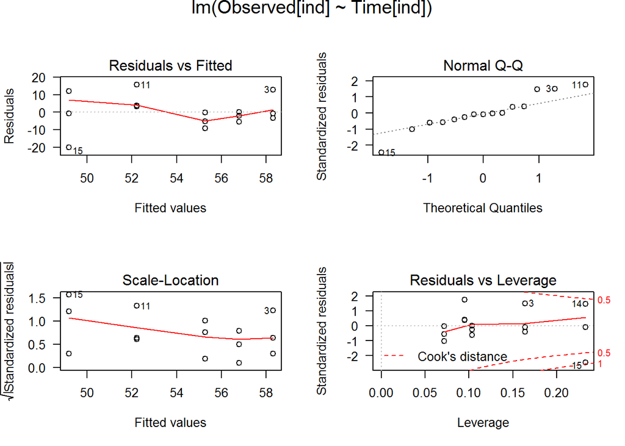

```
## [1] "weighted linear regression for substrate = 75"
## Call:
## rlm(formula = Observed[ind] ~ Time[ind])
## Converged in 11 iterations
##
## Coefficients:
## (Intercept)   Time[ind]
## 56.19939386 -0.04860932
##
## Degrees of freedom: 15 total; 13 residual
## Scale estimate: 4.97
##
## Call: rlm(formula = Observed[ind] ~ Time[ind])
## Residuals:
##      Min       1Q   Median       3Q      Max
## -22.8658  -3.7648   0.1958   2.4030  14.9911
##
## Coefficients:
##             Value   Std. Error t value
## (Intercept) 56.1994  3.0801    18.2459
## Time[ind]   -0.0486  0.0608    -0.7993
##
## Residual standard error: 4.971 on 13 degrees of freedom
```

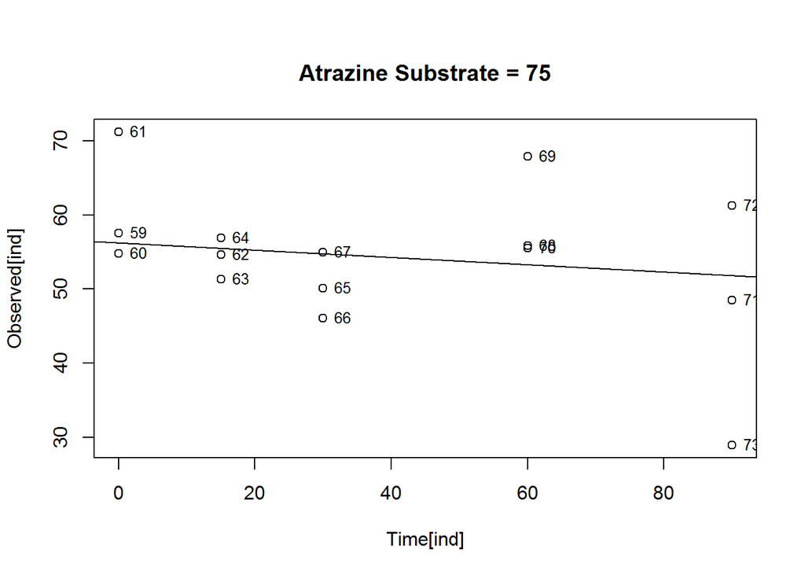

```
## (Intercept)   Time[ind]
## 56.19939386 -0.04860932
##             2.5 % 97.5 %
## (Intercept)    NA     NA
## Time[ind]      NA     NA
## [1] "##################################################"
## [1] "##################################################"
## [1] "Substrate =  100"
##       ind
##  [1,]  74  0 91.15168
##  [2,]  75  0 87.78347
##  [3,]  76  0 88.10440
##  [4,]  77 15 88.83436
##  [5,]  78 15 85.08037
##  [6,]  79 15 83.34356
##  [7,]  80 30 87.40290
##  [8,]  81 30 77.14189
##  [9,]  82 30 81.17033
## [10,]  83 60 82.38969
## [11,]  84 60 78.82099
## [12,]  85 60 74.48075
## [13,]  86 90 81.10749
## [14,]  87 90 72.11741
## [15,]  88 90 74.72567
## [1] "least squares linear regression for substrate = 100"
##
## Call:
## lm(formula = Observed[ind] ~ Time[ind])
##
## Coefficients:
## (Intercept)    Time[ind]
##     87.7853      -0.1421
##
##
## Call:
## lm(formula = Observed[ind] ~ Time[ind])
##
## Residuals:
##     Min      1Q  Median      3Q     Max
## -6.3806 -2.3313 -0.2712  3.1552  6.1106
##
## Coefficients:
##             Estimate Std. Error t value Pr(>|t|)
## (Intercept) 87.78529    1.45078   60.51  < 2e-16 ***
## Time[ind]   -0.14209    0.02865   -4.96 0.000261 ***
## ---
## Signif. codes:  0 '***' 0.001 '**' 0.01 '*' 0.05 '.' 0.1 ' ' 1
##
## Residual standard error: 3.585 on 13 degrees of freedom
## Multiple R-squared:  0.6543, Adjusted R-squared:  0.6277
## F-statistic: 24.61 on 1 and 13 DF,  p-value: 0.0002606
##
## (Intercept)   Time[ind]
##  87.7852945  -0.1420931
##                  2.5 %      97.5 %
## (Intercept) 84.6510853 90.91950363
## Time[ind]   -0.2039779 -0.08020826
```

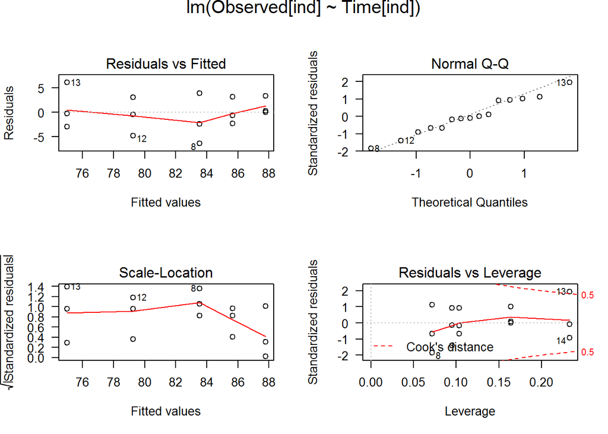

```
## [1] "weighted linear regression for substrate = 100"
## Call:
## rlm(formula = Observed[ind] ~ Time[ind])
## Converged in 11 iterations
##
## Coefficients:
## (Intercept)   Time[ind]
##  87.9249593  -0.1454162
##
## Degrees of freedom: 15 total; 13 residual
## Scale estimate: 4.03
##
## Call: rlm(formula = Observed[ind] ~ Time[ind])
## Residuals:
##     Min      1Q  Median      3Q     Max
## -6.4206 -2.3961 -0.1415  3.1402  6.2700
##
## Coefficients:
##             Value   Std. Error t value
## (Intercept) 87.9250  1.5969    55.0609
## Time[ind]   -0.1454  0.0315    -4.6120
##
## Residual standard error: 4.033 on 13 degrees of freedom
```

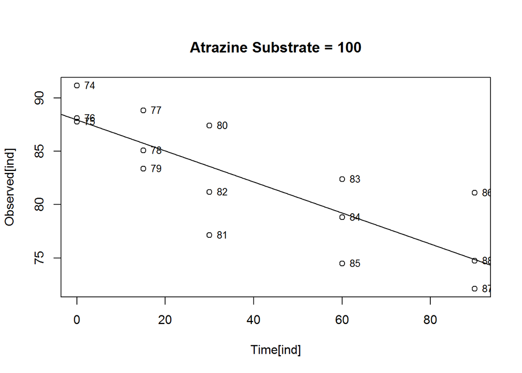

```
## (Intercept)   Time[ind]
##  87.9249593  -0.1454162
##             2.5 % 97.5 %
## (Intercept)    NA     NA
## Time[ind]      NA     NA
## [1] "##################################################"
## [1] "##################################################"
## [1] "Substrate =  125"
##       ind
##  [1,]  89  0 132.1385
##  [2,]  90  0 128.5571
##  [3,]  91 15 127.8622
##  [4,]  92 15 128.3235
##  [5,]  93 30 125.4579
##  [6,]  94 30 124.6120
##  [7,]  95 60 117.3174
##  [8,]  96 60 126.8128
##  [9,]  97 90 118.5064
## [10,]  98 90 117.3016
## [1] "least squares linear regression for substrate = 125"
##
## Call:
## lm(formula = Observed[ind] ~ Time[ind])
##
## Coefficients:
## (Intercept)    Time[ind]
##    129.9684      -0.1354
##
##
## Call:
## lm(formula = Observed[ind] ~ Time[ind])
##
## Residuals:
##     Min      1Q  Median      3Q     Max
## -4.5287 -1.0923 -0.2625  0.6374  4.9666
##
## Coefficients:
##              Estimate Std. Error t value Pr(>|t|)
## (Intercept) 129.96843    1.29571 100.307 1.09e-13 ***
## Time[ind]    -0.13537    0.02558  -5.291 0.000736 ***
## ---
## Signif. codes:  0 '***' 0.001 '**' 0.01 '*' 0.05 '.' 0.1 ' ' 1
##
## Residual standard error: 2.614 on 8 degrees of freedom
## Multiple R-squared:  0.7778, Adjusted R-squared:   0.75
## F-statistic:    28 on 1 and 8 DF,  p-value: 0.0007361
##
## (Intercept)   Time[ind]
## 129.9684341  -0.1353713
##                   2.5 %       97.5 %
## (Intercept) 126.9805276 132.95634051
## Time[ind]    -0.1943674  -0.07637517
```

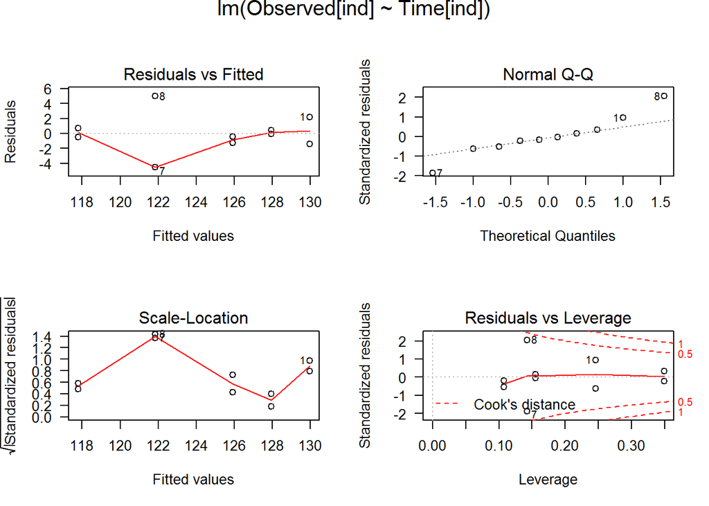

```
## [1] "weighted linear regression for substrate = 125"
## Call:
## rlm(formula = Observed[ind] ~ Time[ind])
## Converged in 4 iterations
##
## Coefficients:
## (Intercept)   Time[ind]
## 129.9094905  -0.1359321
##
## Degrees of freedom: 10 total; 8 residual
## Scale estimate: 1.52
##
## Call: rlm(formula = Observed[ind] ~ Time[ind])
## Residuals:
##     Min      1Q  Median      3Q     Max
## -4.4361 -1.0081 -0.1910  0.7363  5.0592
##
## Coefficients:
##             Value    Std. Error t value
## (Intercept) 129.9095   1.1313   114.8324
## Time[ind]    -0.1359   0.0223    -6.0854
##
## Residual standard error: 1.52 on 8 degrees of freedom
```

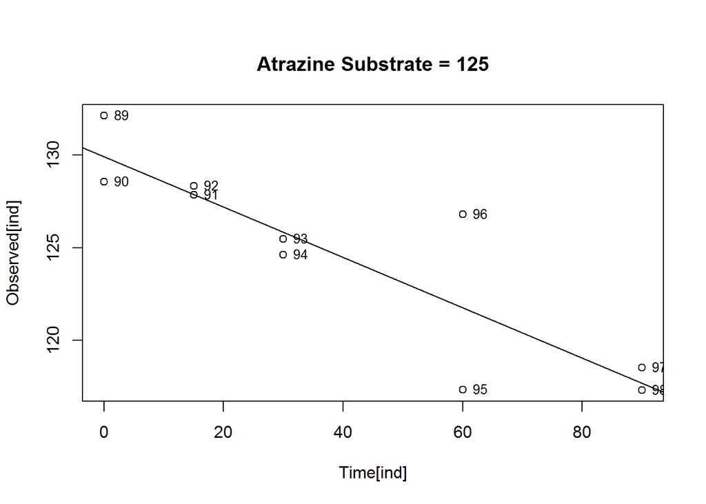

```
## (Intercept)   Time[ind]
## 129.9094905  -0.1359321
##             2.5 % 97.5 %
## (Intercept)    NA     NA
## Time[ind]      NA     NA
## [1] "##################################################"
## [1] "##################################################"
## [1] "Substrate =  150"
##       ind
##  [1,]  99  0 167.6688
##  [2,] 100  0 163.4321
##  [3,] 101  0 170.5737
##  [4,] 102  0 161.3269
##  [5,] 103 15 166.2076
##  [6,] 104 15 172.0808
##  [7,] 105 15 160.6937
##  [8,] 106 15 165.3167
##  [9,] 107 30 159.6171
## [10,] 108 30 163.8883
## [11,] 109 30 163.2166
## [12,] 110 30 147.6768
## [13,] 111 60 158.6096
## [14,] 112 60 155.3368
## [15,] 113 60 164.3544
## [16,] 114 60 154.8116
## [17,] 115 90 144.3980
## [18,] 116 90 157.4613
## [19,] 117 90 158.6914
## [20,] 118 90 142.9719
## [1] "least squares linear regression for substrate = 150"
##
## Call:
## lm(formula = Observed[ind] ~ Time[ind])
##
## Coefficients:
## (Intercept)    Time[ind]
##    166.3323      -0.1645
##
##
## Call:
## lm(formula = Observed[ind] ~ Time[ind])
##
## Residuals:
##     Min      1Q  Median      3Q     Max
## -13.720  -2.968   1.394   2.929   8.216
##
## Coefficients:
##              Estimate Std. Error t value Pr(>|t|)
## (Intercept) 166.33228    2.05831  80.810  < 2e-16 ***
## Time[ind]    -0.16450    0.04064  -4.048 0.000755 ***
## ---
## Signif. codes:  0 '***' 0.001 '**' 0.01 '*' 0.05 '.' 0.1 ' ' 1
##
## Residual standard error: 5.873 on 18 degrees of freedom
## Multiple R-squared:  0.4765, Adjusted R-squared:  0.4474
## F-statistic: 16.38 on 1 and 18 DF,  p-value: 0.0007553
##
## (Intercept)   Time[ind]
## 166.3322788  -0.1645019
##                   2.5 %       97.5 %
## (Intercept) 162.0079348 170.65662281
## Time[ind]    -0.2498859  -0.07911792
```

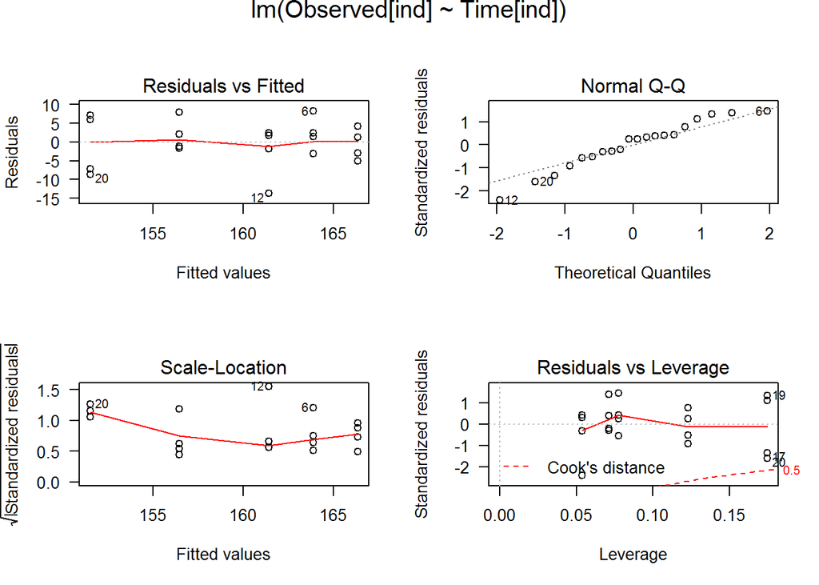

```
## [1] "weighted linear regression for substrate = 150"
## Call:
## rlm(formula = Observed[ind] ~ Time[ind])
## Converged in 9 iterations
##
## Coefficients:
## (Intercept)   Time[ind]
## 166.4937036  -0.1556801
##
## Degrees of freedom: 20 total; 18 residual
## Scale estimate: 4.84
##
## Call: rlm(formula = Observed[ind] ~ Time[ind])
## Residuals:
##     Min      1Q  Median      3Q     Max
## -14.146  -3.162   1.167   2.569   7.922
##
## Coefficients:
##             Value    Std. Error t value
## (Intercept) 166.4937   2.1892    76.0531
## Time[ind]    -0.1557   0.0432    -3.6016
##
## Residual standard error: 4.838 on 18 degrees of freedom
```

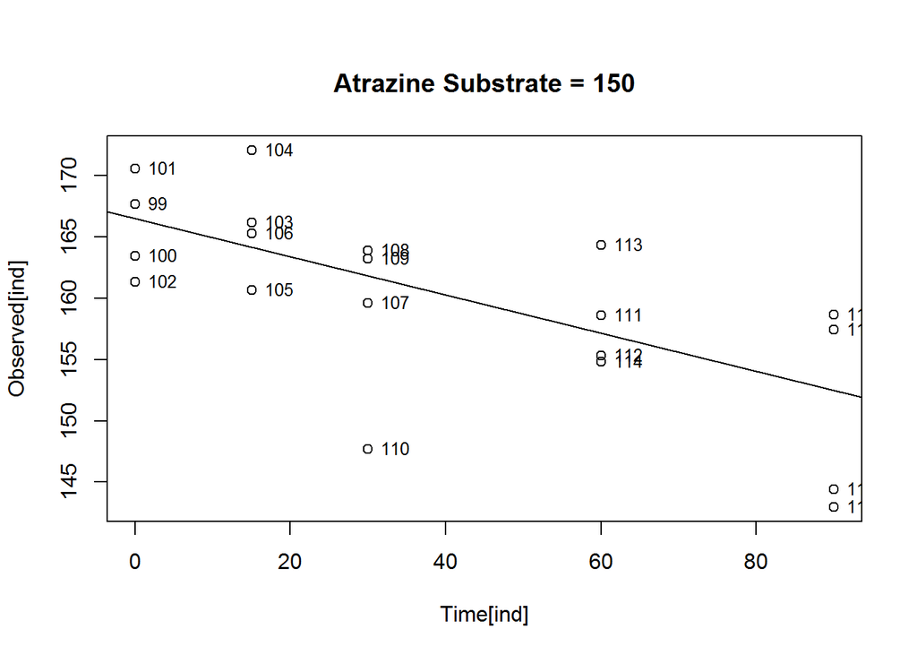

```
## (Intercept)   Time[ind]
## 166.4937036  -0.1556801
##             2.5 % 97.5 %
## (Intercept)    NA     NA
## Time[ind]      NA     NA
## [1] "##################################################"
## [1] "##################################################"
## [1] "Substrate =  250"
##       ind
##  [1,] 119  0 307.3284
##  [2,] 120  0 265.9378
##  [3,] 121 15 291.3287
##  [4,] 122 15 348.5203
##  [5,] 123 15 380.5695
##  [6,] 124 30 264.3975
##  [7,] 125 30 240.4972
##  [8,] 126 60 340.8683
##  [9,] 127 60 244.0251
## [10,] 128 60 274.4346
## [11,] 129 90 289.9871
## [12,] 130 90 240.9444
## [13,] 131 90 327.4026
## [1] "least squares linear regression for substrate = 250"
##
## Call:
## lm(formula = Observed[ind] ~ Time[ind])
##
## Coefficients:
## (Intercept)    Time[ind]
##    304.8179      -0.2638
##
##
## Call:
## lm(formula = Observed[ind] ~ Time[ind])
##
## Residuals:
##     Min      1Q  Median      3Q     Max
## -56.408 -38.880  -9.533  46.324  79.708
##
## Coefficients:
##             Estimate Std. Error t value Pr(>|t|)
## (Intercept) 304.8179    20.9715  14.535 1.59e-08 ***
## Time[ind]    -0.2638     0.3901  -0.676    0.513
## ---
## Signif. codes:  0 '***' 0.001 '**' 0.01 '*' 0.05 '.' 0.1 ' ' 1
##
## Residual standard error: 45.96 on 11 degrees of freedom
## Multiple R-squared:  0.03991,    Adjusted R-squared:  -0.04737
## F-statistic: 0.4572 on 1 and 11 DF,  p-value: 0.5129
##
## (Intercept)   Time[ind]
## 304.8178653  -0.2637669
##                  2.5 %      97.5 %
## (Intercept) 258.659892 350.9758386
## Time[ind]    -1.122323   0.5947897
```

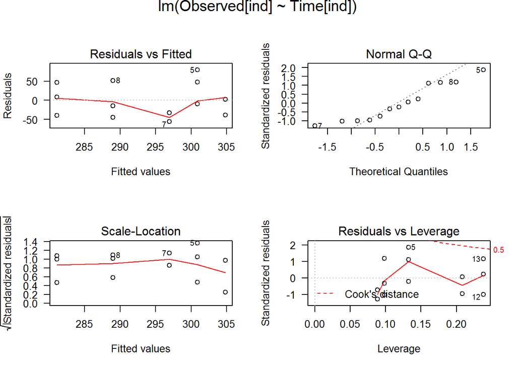

```
## [1] "weighted linear regression for substrate = 250"
## Call:
## rlm(formula = Observed[ind] ~ Time[ind])
## Converged in 1 iterations
##
## Coefficients:
## (Intercept)   Time[ind]
## 304.8178653  -0.2637669
##
## Degrees of freedom: 13 total; 11 residual
## Scale estimate: 59.5
##
## Call: rlm(formula = Observed[ind] ~ Time[ind])
## Residuals:
##     Min      1Q  Median      3Q     Max
## -56.408 -38.880  -9.533  46.324  79.708
##
## Coefficients:
##             Value    Std. Error t value
## (Intercept) 304.8179  20.9715    14.5349
## Time[ind]    -0.2638   0.3901    -0.6762
##
## Residual standard error: 59.5 on 11 degrees of freedom
```

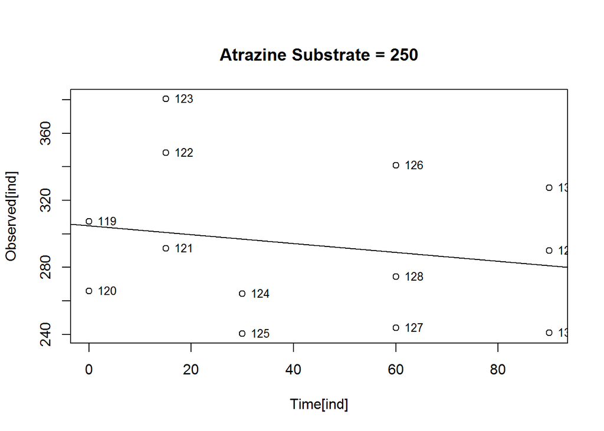

```
## (Intercept)   Time[ind]
## 304.8178653  -0.2637669
##             2.5 % 97.5 %
## (Intercept)    NA     NA
## Time[ind]      NA     NA
## [1] "##################################################"
```

```
## 'data.frame':    9 obs. of  2 variables:
##  $ sub: num  0.712 10 3.168 50 75 ...
##  $ vel: num  46.1 153.2 113.8 237.6 243 ...
##        sub        vel
## 1   0.7120   46.06058
## 2  10.0000  153.17362
## 3   3.1684  113.78122
## 4  50.0000  237.60942
## 5  75.0000  243.04658
## 6 100.0000  727.08109
## 7 125.0000  679.66027
## 8 150.0000  778.40045
## 9 250.0000 1318.83430
```

```
## [1] "here are the rates"
```

```
##
## Model fitted: Michaelis-Menten (2 parms)
##
## Parameter estimates:
##
##               Estimate Std. Error t-value p-value
## d:(Intercept)  20316.8    56747.7  0.3580  0.7309
## e:(Intercept)   3608.1    10593.6  0.3406  0.7434
##
## Residual standard error:
##
##  109.7349 (7 degrees of freedom)
```

```
## No test available
##
##           ModelDf Log lik Df Chisq value p value
##
## DRC model
```

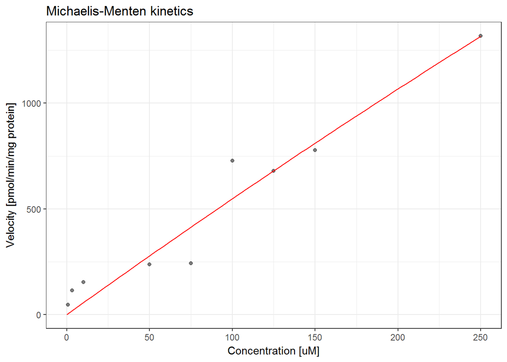

We are interested in the reaction rate, v, which is a function of available substrate (pesticide) and the presence of an enzyme. We get Vmax from the asymptote and K = 0.5*Vmax. Biochemical reactions with a single substrate are typically assumed to follow Michaelis-Menten kinetics even if they deviate from the basic model assumptions.

We are fitting the 2-parameter model.

Used to estimate slopes.

# dea

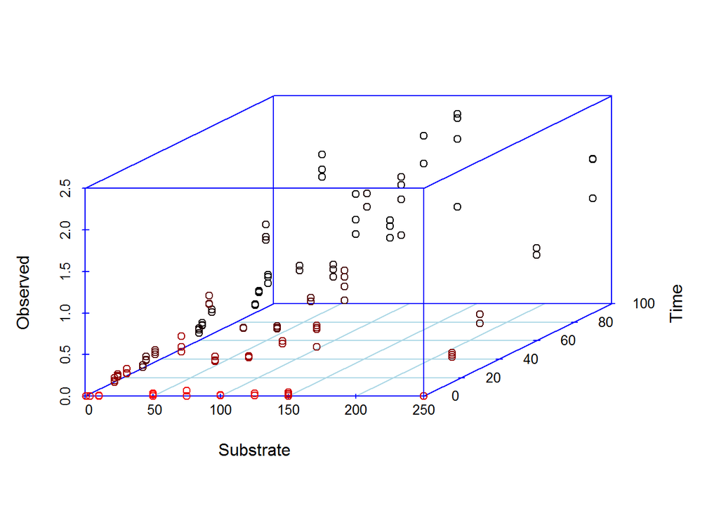

The above figure shows a three-dimensional plot of pesticide substrate concentration, observed concentration and experiment time. We need to condition the pesticide data on the substrate concentrations used in the experiment and regress the observed concentrations over the 90 min period in order to estimate the linear slopes for the Michaelis-Menten kinetic rate constants.

```
## [1] "Substrates:"
```

```
## [1] "##################################################"
## [1] "Substrate =  50"
##  [1] "Indices =  1"  "Indices =  2"  "Indices =  3"  "Indices =  4"
##  [5] "Indices =  5"  "Indices =  6"  "Indices =  7"  "Indices =  8"
##  [9] "Indices =  9"  "Indices =  10" "Indices =  11" "Indices =  12"
## [13] "Indices =  13" "Indices =  14" "Indices =  15"
##  [1] "Times = 0"  "Times = 0"  "Times = 0"  "Times = 15" "Times = 15"
##  [6] "Times = 15" "Times = 30" "Times = 30" "Times = 30" "Times = 60"
## [11] "Times = 60" "Times = 60" "Times = 90" "Times = 90" "Times = 90"
##  [1] "Concs = 0.036297037" "Concs = 0.020155338" "Concs = 0"
##  [4] "Concs = 0.556132535" "Concs = 0.426402494" "Concs = 0.367645414"
##  [7] "Concs = 0.875251483" "Concs = 0.773924251" "Concs = 0.782702264"
## [10] "Concs = 1.213136274" "Concs = 1.251229589" "Concs = 1.396543005"
## [13] "Concs = 1.905345081" "Concs = 1.728273154" "Concs = 1.633832066"
## Call:
## rlm(formula = Observed[ind] ~ Time[ind])
## Converged in 4 iterations
##
## Coefficients:
## (Intercept)   Time[ind]
##  0.13401337  0.01873467
##
## Degrees of freedom: 15 total; 13 residual
## Scale estimate: 0.136
##
## Call: rlm(formula = Observed[ind] ~ Time[ind])
## Residuals:
##       Min        1Q    Median        3Q       Max
## -0.186302 -0.094788 -0.006864  0.085930  0.179198
##
## Coefficients:
##             Value   Std. Error t value
## (Intercept)  0.1340  0.0514     2.6076
## Time[ind]    0.0187  0.0010    18.4625
##
## Residual standard error: 0.1362 on 13 degrees of freedom
```

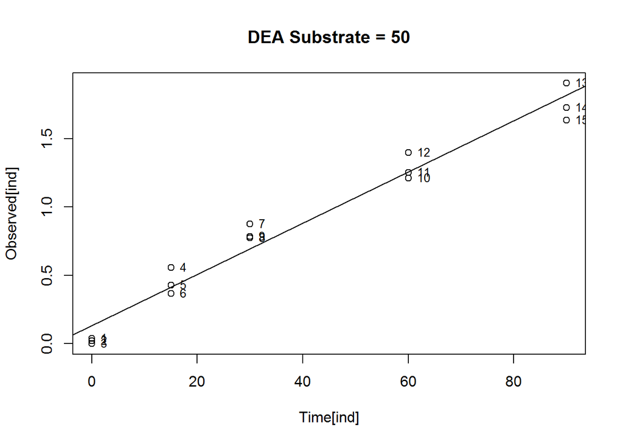

```
## (Intercept)   Time[ind]
##  0.13401337  0.01873467
##             2.5 % 97.5 %
## (Intercept)    NA     NA
## Time[ind]      NA     NA
## [1] "##################################################"
## [1] "##################################################"
## [1] "Substrate =  10"
##  [1] "Indices =  16" "Indices =  17" "Indices =  18" "Indices =  19"
##  [5] "Indices =  20" "Indices =  21" "Indices =  22" "Indices =  23"
##  [9] "Indices =  24" "Indices =  25" "Indices =  26" "Indices =  27"
## [13] "Indices =  28" "Indices =  29" "Indices =  30"
##  [1] "Times = 0"  "Times = 0"  "Times = 0"  "Times = 15" "Times = 15"
##  [6] "Times = 15" "Times = 30" "Times = 30" "Times = 30" "Times = 60"
## [11] "Times = 60" "Times = 60" "Times = 90" "Times = 90" "Times = 90"
##  [1] "Concs = 0"           "Concs = 0.008626567" "Concs = 0"
##  [4] "Concs = 0.103194408" "Concs = 0.112578897" "Concs = 0.159184181"
##  [7] "Concs = 0.221372739" "Concs = 0.168939786" "Concs = 0.193731234"
## [10] "Concs = NA"          "Concs = 0.341243934" "Concs = 0.378947201"
## [13] "Concs = 0.359831218" "Concs = 0.432928865" "Concs = 0.459337307"
## Call:
## rlm(formula = Observed[ind] ~ Time[ind])
## Converged in 6 iterations
##
## Coefficients:
## (Intercept)   Time[ind]
## 0.037411413 0.004672527
##
## Degrees of freedom: 14 total; 12 residual
##   (1 observation deleted due to missingness)
## Scale estimate: 0.0399
##
## Call: rlm(formula = Observed[ind] ~ Time[ind])
## Residuals:
##       Min        1Q    Median        3Q       Max
## -0.098108 -0.027841 -0.001453  0.021647  0.061184
##
## Coefficients:
##             Value   Std. Error t value
## (Intercept)  0.0374  0.0174     2.1461
## Time[ind]    0.0047  0.0003    13.3781
##
## Residual standard error: 0.03987 on 12 degrees of freedom
##   (1 observation deleted due to missingness)
```

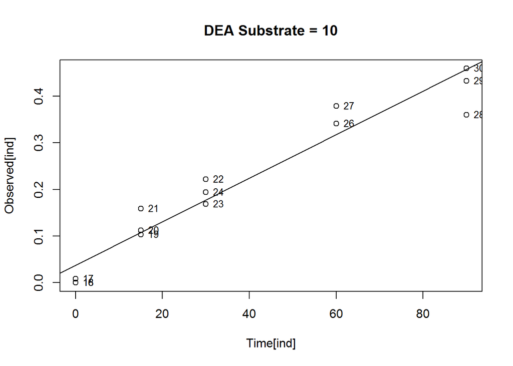

```
## (Intercept)   Time[ind]
## 0.037411413 0.004672527
##             2.5 % 97.5 %
## (Intercept)    NA     NA
## Time[ind]      NA     NA
## [1] "##################################################"
## [1] "##################################################"
## [1] "Substrate =  100"
##  [1] "Indices =  31" "Indices =  32" "Indices =  33" "Indices =  34"
##  [5] "Indices =  35" "Indices =  36" "Indices =  37" "Indices =  38"
##  [9] "Indices =  39" "Indices =  40" "Indices =  41" "Indices =  42"
## [13] "Indices =  43" "Indices =  44" "Indices =  45"
##  [1] "Times = 0"  "Times = 0"  "Times = 0"  "Times = 15" "Times = 15"
##  [6] "Times = 15" "Times = 30" "Times = 30" "Times = 30" "Times = 60"
## [11] "Times = 60" "Times = 60" "Times = 90" "Times = 90" "Times = 90"
##  [1] "Concs = 0.010932763" "Concs = 0.00906186"  "Concs = 0.011427564"
##  [4] "Concs = 0.317229914" "Concs = 0.297863205" "Concs = 0.30576652"
##  [7] "Concs = 0.490665066" "Concs = 0.510387221" "Concs = 0.480437347"
## [10] "Concs = 0.85701012"  "Concs = 0.914180319" "Concs = 0.767670679"
## [13] "Concs = 1.119176244" "Concs = 0.905643096" "Concs = 1.044016346"
## Call:
## rlm(formula = Observed[ind] ~ Time[ind])
## Converged in 6 iterations
##
## Coefficients:
## (Intercept)   Time[ind]
##  0.10072516  0.01127992
##
## Degrees of freedom: 15 total; 13 residual
## Scale estimate: 0.106
##
## Call: rlm(formula = Observed[ind] ~ Time[ind])
## Residuals:
##      Min       1Q   Median       3Q      Max
## -0.21028 -0.08060  0.02794  0.04942  0.13666
##
## Coefficients:
##             Value   Std. Error t value
## (Intercept)  0.1007  0.0362     2.7845
## Time[ind]    0.0113  0.0007    15.7929
##
## Residual standard error: 0.1057 on 13 degrees of freedom
```

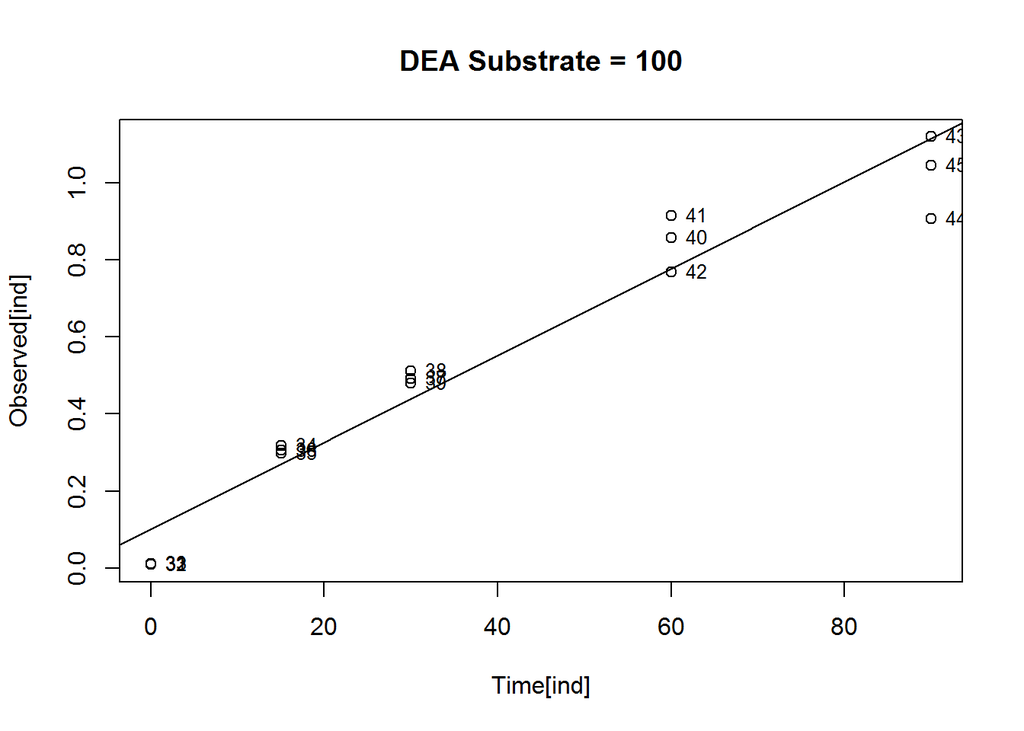

```
## (Intercept)   Time[ind]
##  0.10072516  0.01127992
##             2.5 % 97.5 %
## (Intercept)    NA     NA
## Time[ind]      NA     NA
## [1] "##################################################"
## [1] "##################################################"
## [1] "Substrate =  75"
##  [1] "Indices =  46" "Indices =  47" "Indices =  48" "Indices =  49"
##  [5] "Indices =  50" "Indices =  51" "Indices =  52" "Indices =  53"
##  [9] "Indices =  54" "Indices =  55" "Indices =  56" "Indices =  57"
## [13] "Indices =  58" "Indices =  59" "Indices =  60"
##  [1] "Times = 0"  "Times = 0"  "Times = 0"  "Times = 15" "Times = 15"
##  [6] "Times = 15" "Times = 30" "Times = 30" "Times = 30" "Times = 60"
## [11] "Times = 60" "Times = 60" "Times = 90" "Times = 90" "Times = 90"
##  [1] "Concs = 0.06413735"  "Concs = 0"           "Concs = 0"
##  [4] "Concs = 0.265350105" "Concs = 0.252666719" "Concs = 0.310628256"
##  [7] "Concs = 0.489641626" "Concs = 0.484022887" "Concs = 0.487698201"
## [10] "Concs = 0.844772967" "Concs = 0.903936454" "Concs = 0.905600859"
## [13] "Concs = 1.124440012" "Concs = 1.429855138" "Concs = 0.946655192"
## Call:
## rlm(formula = Observed[ind] ~ Time[ind])
## Converged in 12 iterations
##
## Coefficients:
## (Intercept)   Time[ind]
##  0.06356831  0.01316417
##
## Degrees of freedom: 15 total; 13 residual
## Scale estimate: 0.0735
##
## Call: rlm(formula = Observed[ind] ~ Time[ind])
## Residuals:
##       Min        1Q    Median        3Q       Max
## -0.301688 -0.036107  0.004319  0.040373  0.181512
##
## Coefficients:
##             Value   Std. Error t value
## (Intercept)  0.0636  0.0318     2.0008
## Time[ind]    0.0132  0.0006    20.9847
##
## Residual standard error: 0.07353 on 13 degrees of freedom
```

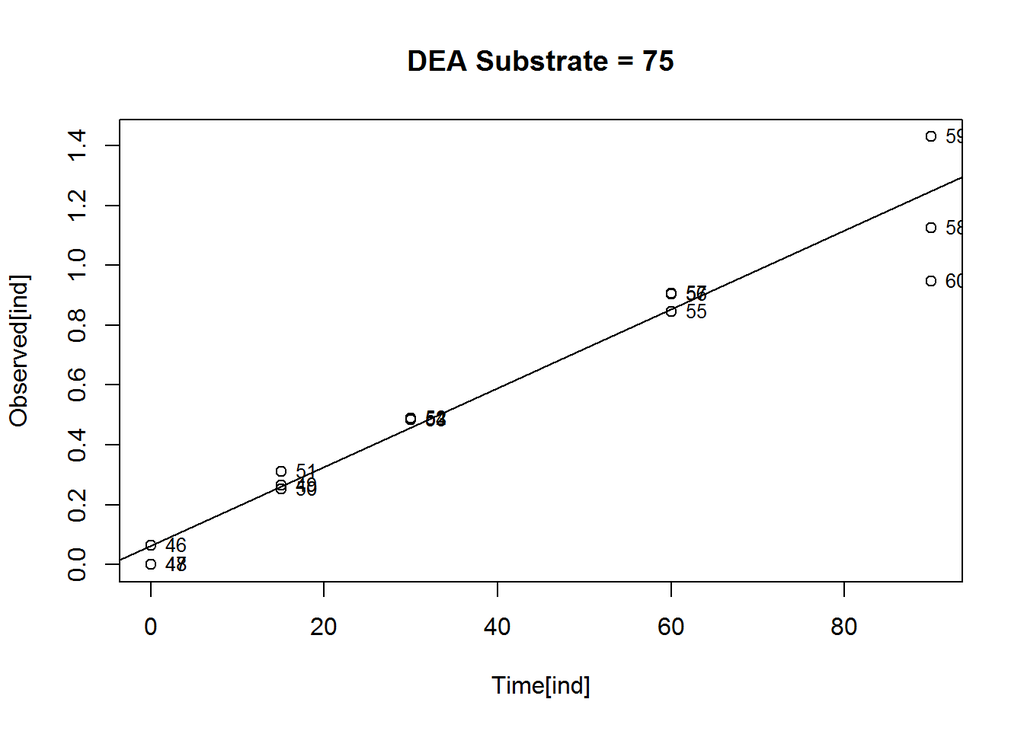

```
## (Intercept)   Time[ind]
##  0.06356831  0.01316417
##             2.5 % 97.5 %
## (Intercept)    NA     NA
## Time[ind]      NA     NA
## [1] "##################################################"
## [1] "##################################################"
## [1] "Substrate =  125"
##  [1] "Indices =  61" "Indices =  62" "Indices =  63" "Indices =  64"
##  [5] "Indices =  65" "Indices =  66" "Indices =  67" "Indices =  68"
##  [9] "Indices =  69" "Indices =  70" "Indices =  71"
##  [1] "Times = 0"  "Times = 0"  "Times = 0"  "Times = 15" "Times = 15"
##  [6] "Times = 30" "Times = 30" "Times = 60" "Times = 60" "Times = 90"
## [11] "Times = 90"
##  [1] "Concs = NA"          "Concs = 0.007921774" "Concs = 0.031483454"
##  [4] "Concs = 0.494202961" "Concs = 0.462344121" "Concs = 0.807147968"
##  [7] "Concs = 0.848352727" "Concs = 1.611138851" "Concs = 1.76792633"
## [10] "Concs = 2.133194979" "Concs = 1.795991956"
## Call:
## rlm(formula = Observed[ind] ~ Time[ind])
## Converged in 6 iterations
##
## Coefficients:
## (Intercept)   Time[ind]
##  0.10230072  0.02323912
##
## Degrees of freedom: 10 total; 8 residual
##   (1 observation deleted due to missingness)
## Scale estimate: 0.0974
##
## Call: rlm(formula = Observed[ind] ~ Time[ind])
## Residuals:
##       Min        1Q    Median        3Q       Max
## -0.397829 -0.068269  0.009565  0.047488  0.271279
##
## Coefficients:
##             Value   Std. Error t value
## (Intercept)  0.1023  0.0610     1.6780
## Time[ind]    0.0232  0.0012    19.3057
##
## Residual standard error: 0.09744 on 8 degrees of freedom
##   (1 observation deleted due to missingness)
```

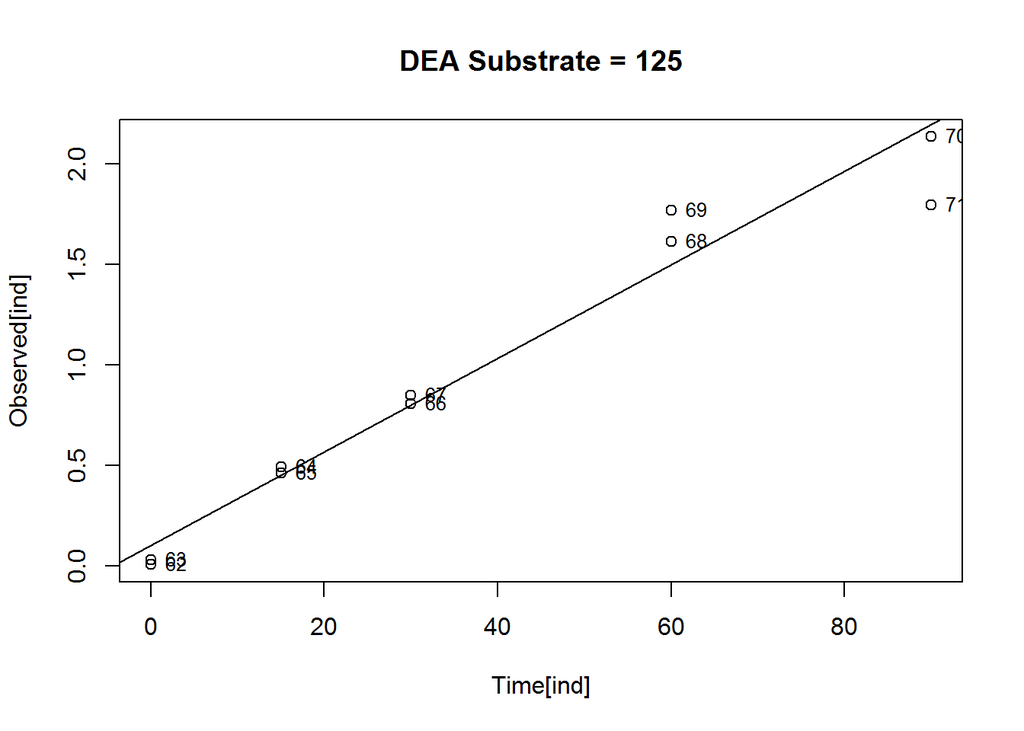

```
## (Intercept)   Time[ind]
##  0.10230072  0.02323912
##             2.5 % 97.5 %
## (Intercept)    NA     NA
## Time[ind]      NA     NA
## [1] "##################################################"
## [1] "##################################################"
## [1] "Substrate =  0.712"
##  [1] "Indices =  72" "Indices =  73" "Indices =  74" "Indices =  75"
##  [5] "Indices =  76" "Indices =  77" "Indices =  78" "Indices =  79"
##  [9] "Indices =  80" "Indices =  81" "Indices =  82" "Indices =  83"
## [13] "Indices =  84" "Indices =  85"
##  [1] "Times = 0"  "Times = 0"  "Times = 0"  "Times = 15" "Times = 15"
##  [6] "Times = 15" "Times = 30" "Times = 30" "Times = 30" "Times = 60"
## [11] "Times = 60" "Times = 60" "Times = 90" "Times = 90"
##  [1] "Concs = 0"           "Concs = 0"           "Concs = 0"
##  [4] "Concs = 0"           "Concs = 0.052966765" "Concs = 0.022152242"
##  [7] "Concs = 0.042043283" "Concs = 0.017249246" "Concs = 0.040066167"
## [10] "Concs = 0.151616937" "Concs = 0.090030163" "Concs = 0.131931926"
## [13] "Concs = 0.09273422"  "Concs = 0.109945027"
## Call:
## rlm(formula = Observed[ind] ~ Time[ind])
## Converged in 10 iterations
##
## Coefficients:
## (Intercept)   Time[ind]
## 0.001771916 0.001289181
##
## Degrees of freedom: 14 total; 12 residual
## Scale estimate: 0.0139
##
## Call: rlm(formula = Observed[ind] ~ Time[ind])
## Residuals:
##       Min        1Q    Median        3Q       Max
## -0.025064 -0.006333 -0.001077  0.008580  0.072494
##
## Coefficients:
##             Value  Std. Error t value
## (Intercept) 0.0018 0.0111     0.1600
## Time[ind]   0.0013 0.0002     5.4207
##
## Residual standard error: 0.01391 on 12 degrees of freedom
```

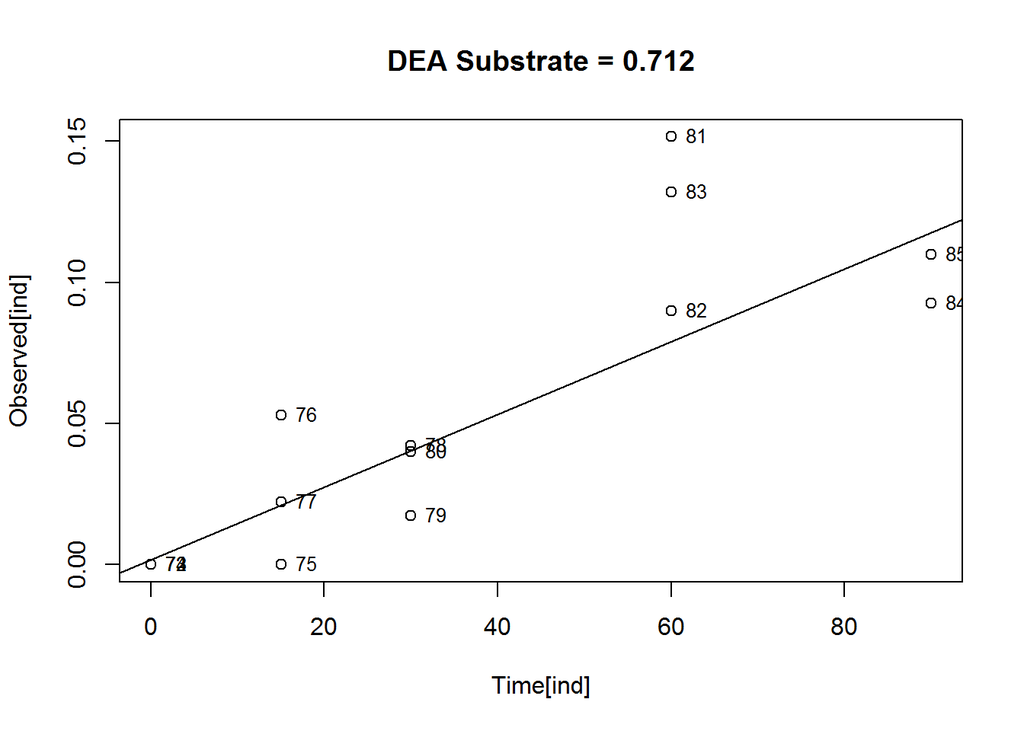

```
## (Intercept)   Time[ind]
## 0.001771916 0.001289181
##             2.5 % 97.5 %
## (Intercept)    NA     NA
## Time[ind]      NA     NA
## [1] "##################################################"
## [1] "##################################################"
## [1] "Substrate =  3.1684"
##  [1] "Indices =  86" "Indices =  87" "Indices =  88" "Indices =  89"
##  [5] "Indices =  90" "Indices =  91" "Indices =  92" "Indices =  93"
##  [9] "Indices =  94" "Indices =  95" "Indices =  96" "Indices =  97"
## [13] "Indices =  98" "Indices =  99"
##  [1] "Times = 0"  "Times = 0"  "Times = 15" "Times = 15" "Times = 15"
##  [6] "Times = 30" "Times = 30" "Times = 30" "Times = 60" "Times = 60"
## [11] "Times = 60" "Times = 90" "Times = 90" "Times = 90"
##  [1] "Concs = 0"           "Concs = 0"           "Concs = 0.081663688"
##  [4] "Concs = 0.098250742" "Concs = 0.064161633" "Concs = 0.107585902"
##  [7] "Concs = 0.09756452"  "Concs = 0.142322491" "Concs = 0.191711135"
## [10] "Concs = 0.185437222" "Concs = 0.21711368"  "Concs = 0.265270616"
## [13] "Concs = 0.260794682" "Concs = 0.246155621"
## Call:
## rlm(formula = Observed[ind] ~ Time[ind])
## Converged in 10 iterations
##
## Coefficients:
## (Intercept)   Time[ind]
##  0.02743315  0.00266125
##
## Degrees of freedom: 14 total; 12 residual
## Scale estimate: 0.0178
##
## Call: rlm(formula = Observed[ind] ~ Time[ind])
## Residuals:
##       Min        1Q    Median        3Q       Max
## -0.027433 -0.008817 -0.001673  0.011885  0.035052
##
## Coefficients:
##             Value   Std. Error t value
## (Intercept)  0.0274  0.0131     2.0982
## Time[ind]    0.0027  0.0002    10.6704
##
## Residual standard error: 0.0178 on 12 degrees of freedom
```

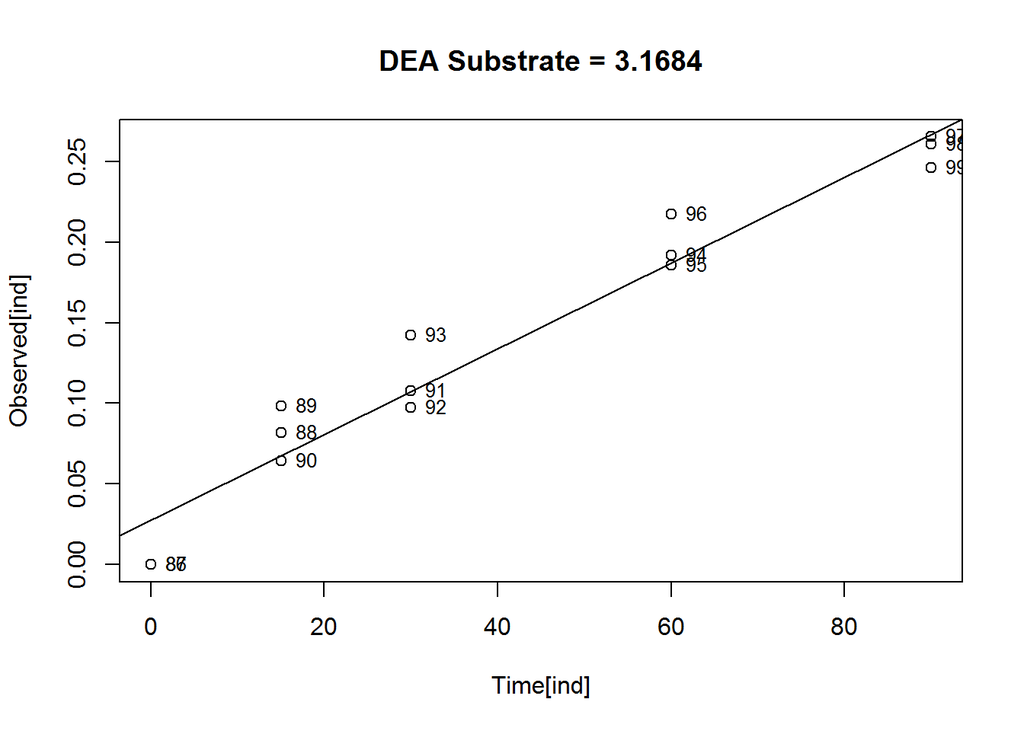

```
## (Intercept)   Time[ind]
##  0.02743315  0.00266125
##             2.5 % 97.5 %
## (Intercept)    NA     NA
## Time[ind]      NA     NA
## [1] "##################################################"
## [1] "##################################################"
## [1] "Substrate =  250"
##  [1] "Indices =  100" "Indices =  101" "Indices =  102" "Indices =  103"
##  [5] "Indices =  104" "Indices =  105" "Indices =  106" "Indices =  107"
##  [9] "Indices =  108" "Indices =  109" "Indices =  110" "Indices =  111"
## [13] "Indices =  112"
##  [1] "Times = 0"  "Times = 0"  "Times = 0"  "Times = 15" "Times = 15"
##  [6] "Times = 15" "Times = 30" "Times = 30" "Times = 60" "Times = 60"
## [11] "Times = 90" "Times = 90" "Times = 90"
##  [1] "Concs = 0"           "Concs = 0"           "Concs = 0"
##  [4] "Concs = 0.304504501" "Concs = 0.327456277" "Concs = 0.357391952"
##  [7] "Concs = 0.649535281" "Concs = 0.541989813" "Concs = 1.114144819"
## [10] "Concs = 1.032829952" "Concs = 1.857454502" "Concs = 1.848929556"
## [13] "Concs = 1.381369076"
## Call:
## rlm(formula = Observed[ind] ~ Time[ind])
## Converged in 11 iterations
##
## Coefficients:
## (Intercept)   Time[ind]
## 0.009238479 0.019350499
##
## Degrees of freedom: 13 total; 11 residual
## Scale estimate: 0.0832
##
## Call: rlm(formula = Observed[ind] ~ Time[ind])
## Residuals:
##       Min        1Q    Median        3Q       Max
## -0.369414 -0.047764 -0.009238  0.057896  0.106671
##
## Coefficients:
##             Value   Std. Error t value
## (Intercept)  0.0092  0.0372     0.2482
## Time[ind]    0.0194  0.0007    26.5778
##
## Residual standard error: 0.08323 on 11 degrees of freedom
```

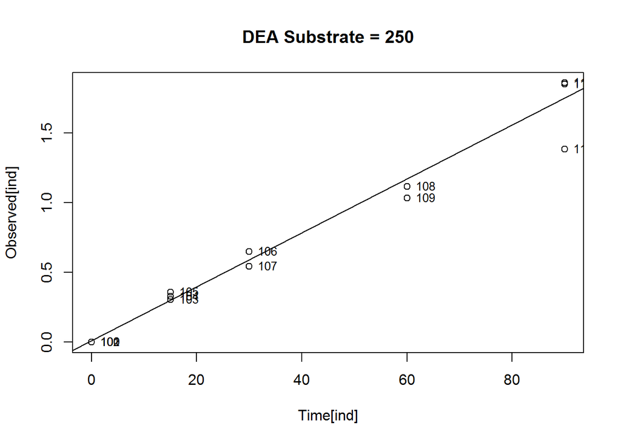

```
## (Intercept)   Time[ind]
## 0.009238479 0.019350499
##             2.5 % 97.5 %
## (Intercept)    NA     NA
## Time[ind]      NA     NA
## [1] "##################################################"
## [1] "##################################################"
## [1] "Substrate =  150"
##  [1] "Indices =  113" "Indices =  114" "Indices =  115" "Indices =  116"
##  [5] "Indices =  117" "Indices =  118" "Indices =  119" "Indices =  120"
##  [9] "Indices =  121" "Indices =  122" "Indices =  123" "Indices =  124"
## [13] "Indices =  125" "Indices =  126" "Indices =  127" "Indices =  128"
## [17] "Indices =  129" "Indices =  130" "Indices =  131" "Indices =  132"
##  [1] "Times = 0"  "Times = 0"  "Times = 0"  "Times = 0"  "Times = 15"
##  [6] "Times = 15" "Times = 15" "Times = 15" "Times = 30" "Times = 30"
## [11] "Times = 30" "Times = 30" "Times = 60" "Times = 60" "Times = 60"
## [16] "Times = 60" "Times = 90" "Times = 90" "Times = 90" "Times = 90"
##  [1] "Concs = 0.019939329" "Concs = 0.048466882" "Concs = 0.026079286"
##  [4] "Concs = 0"           "Concs = 0.634852481" "Concs = 0.425731557"
##  [7] "Concs = 0.685758141" "Concs = 0.655886478" "Concs = 1.175719405"
## [10] "Concs = 0.819943874" "Concs = 1.100162014" "Concs = 0.985930582"
## [13] "Concs = 1.968440394" "Concs = 1.271576575" "Concs = 1.873663272"
## [16] "Concs = 1.701164984" "Concs = 2.39611731"  "Concs = 1.275943895"
## [19] "Concs = 2.093301823" "Concs = 2.344177507"
## Call:
## rlm(formula = Observed[ind] ~ Time[ind])
## Converged in 6 iterations
##
## Coefficients:
## (Intercept)   Time[ind]
##  0.18458313  0.02376598
##
## Degrees of freedom: 20 total; 18 residual
## Scale estimate: 0.225
##
## Call: rlm(formula = Observed[ind] ~ Time[ind])
## Residuals:
##      Min       1Q   Median       3Q      Max
## -1.04758 -0.16004  0.04663  0.12228  0.35790
##
## Coefficients:
##             Value   Std. Error t value
## (Intercept)  0.1846  0.0830     2.2229
## Time[ind]    0.0238  0.0016    14.4951
##
## Residual standard error: 0.2248 on 18 degrees of freedom
```

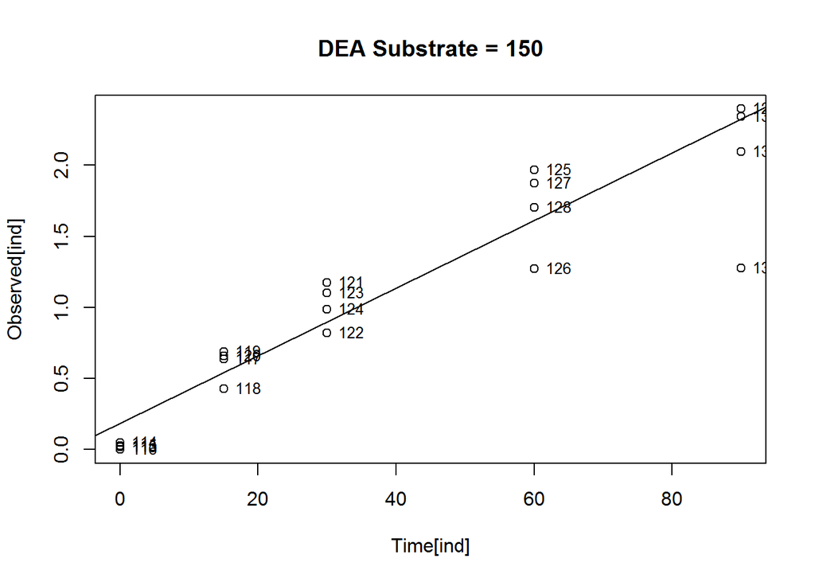

```
## (Intercept)   Time[ind]
##  0.18458313  0.02376598
##             2.5 % 97.5 %
## (Intercept)    NA     NA
## Time[ind]      NA     NA
## [1] "##################################################"
```

```
## 'data.frame':    9 obs. of  2 variables:
##  $ sub: num  50 10 100 75 125 ...
##  $ vel: num  93.7 23.4 56.4 65.8 116.2 ...
##        sub        vel
## 1  50.0000  93.673356
## 2  10.0000  23.362635
## 3 100.0000  56.399623
## 4  75.0000  65.820831
## 5 125.0000 116.195578
## 6   0.7120   6.445907
## 7   3.1684  13.306248
## 8 250.0000  96.752493
## 9 150.0000 118.829886
```

```
## [1] "here are the rates"
```

```
##
## Model fitted: Michaelis-Menten (2 parms)
##
## Parameter estimates:
##
##               Estimate Std. Error t-value p-value
## d:(Intercept)  119.069     24.416  4.8767  0.0018 **
## e:(Intercept)   31.905     25.855  1.2340  0.2570
## ---
## Signif. codes:  0 '***' 0.001 '**' 0.01 '*' 0.05 '.' 0.1 ' ' 1
##
## Residual standard error:
##
##  20.38128 (7 degrees of freedom)
```

```
## No test available
##
##           ModelDf Log lik Df Chisq value p value
##
## DRC model
```

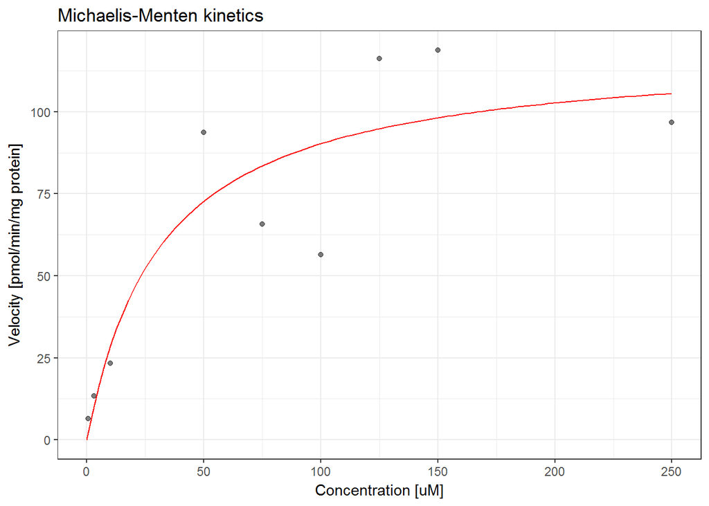

We are interested in the reaction rate, v, which is a function of available substrate (pesticide) and the presence of an enzyme. We get Vmax from the asymptote and K = 0.5*Vmax. Biochemical reactions with a single substrate are typically assumed to follow Michaelis-Menten kinetics even if they deviate from the basic model assumptions.

We are fitting the 2-parameter model.

Used to estimate slopes.